# Charter 2013

rjs8

07/30/2018

```r
set.seed(42)
data_2013 = read.dbf("data/api13gdb.dbf")
```

## The Data Source

The file used for this analysis is at https://www.cde.ca.gov/ta/ac/ap/apidatafiles.asp, specifically, the “2013 Growth API”.

## Response

The response variable for this analysis is going to be `API13`.

## Predictors

We start out by looking at the data and removing any rows that have missing data since we would be unable to provide estimates for their values.

```r
# Clean up rows with NAs
#data_2013=na.omit(data_2013) # apparently there are NAs in every row; this gave me an empty dataframe

# First get the subset that the documentation says has valid statistical data,
# then remove the FLAG column because we don't need it anymore.
# Also remove the other alternative responses related to growth and APIs.
data_2013 = subset(data_2013, subset = is.na(data_2013$FLAG), select = !(colnames(data_2013) %in% c('FLAG','API12','TARGET','GROWTH','SCH_WIDE','COMP_IMP','BOTH')))
nrow(data_2013)
```

```
## [1] 9948
```

```r
#
# Utility functions to manipulate the data.
#

# Function to remove exact column names
remove_columns = function(dframe, columns_to_remove) {
  subset(dframe, select = !(colnames(dframe) %in% columns_to_remove))
}

# Function to remove matching column names
remove_columns_like = function(dframe, columns_to_remove) {
  tmp_df = data.frame(dframe)
  for(match in columns_to_remove) {
    tmp_df = subset(tmp_df, select = -grep(match, colnames(tmp_df), perl=TRUE, value=FALSE))
  }
  tmp_df
}

# threshold is a number from 0 to 1 to indicate how much NA you want to see
# threshold = 0.7 means show columns with 70% NAs
show_columns_with_na = function(dframe, threshold) {
  cn = colnames(dframe)
  col_na_ratios = rep(0, length(cn))
  for(c in 1:length(cn)) {
    col_na_ratios[c] = mean(is.na(dframe[,cn[c]]))
  }
  print(cn[col_na_ratios > threshold])
  cn[col_na_ratios > threshold]
}
```

```r
# Remove all _TARG, _MET, _SIG, _API12, _API13 columns which are just metadata about whether targets were met
# or whether columns were significant.
data_2013 = remove_columns_like(data_2013, c("_TARG", "_MET", "_SIG", "_API12", "_API13", "_NUM", "_GROW"))

# Remove schools designated as small for GROWTH and BASE purposes. It uses NA to mean not-small.
data_2013 = subset(data_2013, subset = is.na(data_2013$SM12) & is.na(data_2013$SM13), select = !(colnames(data_2013) %in% c('SM12','SM13')))

# Remove schools with SIZE = S or T which indicate non-valid API scores
data_2013 = subset(data_2013, subset = !(data_2013$SIZE %in% c("S","T")), select =!(colnames(data_2013) %in% c('SIZE')))

# Transform CHARTER column to indicate Y or N because it uses NA to indicate a non-charter school
data_2013$CHARTER = as.factor(ifelse(is.na(data_2013$CHARTER), "N", "Y"))


# Transform SPED column by setting NA to 'R' for regular b/c it uses NA to indicate regular schools
data_2013$SPED = as.factor(ifelse(is.na(data_2013$SPED), "R", data_2013$SPED))

# Transform STYPE column by setting NA to 'O' to indicate other
data_2013$STYPE = as.factor(ifelse(is.na(data_2013$STYPE), "O", data_2013$STYPE))

# Remove the names because we have the school id in the first column
data_2013 = remove_columns(data_2013, c("SNAME", "DNAME", "CNAME"))

# Remove rows with YR_RND = Yes because they have mostly NA columns
data_2013 = subset(data_2013, subset = data_2013$YR_RND != 'Yes', select =!(colnames(data_2013) %in% c('YR_RND')))

# Remove rows with AVG_ED = NA because there's not that much of them (37)
data_2013 = subset(data_2013, subset = !is.na(data_2013$AVG_ED))

# Remove rows with st_rank and sim_rank = NA b/c there's not that much of them (1 each)
data_2013 = subset(data_2013, subset = !is.na(data_2013$st_rank) & !is.na(data_2013$sim_rank))

# Remove rows with MEDIAN13 or MEDIAN12 = NA
data_2013 = subset(data_2013, subset = !is.na(data_2013$MEDIAN13) | !is.na(data_2013$MEDIAN12))

# Iterate with any columns that have NAs: either transfrom the NA to something else,
# or remove the column, or remove the row.
# Remove columns if they don't look like they're needed according to this dataset's record layout
# (https://www.cde.ca.gov/ta/ac/ap/reclayout13g.asp)

other_cols = show_columns_with_na(data_2013, 0)
```

```
## [1] "chg_data" "IRG5"
```

```r
data_2013 = remove_columns(data_2013, other_cols)

nrow(data_2013)
```

```
## [1] 7431
```

Next step is to convert numeric columns back to NUM and factor columns to FACTOR.

```r
num_columns = c('CDS','VALID','API13','PCT_AA','PCT_AI','PCT_AS','PCT_FI','PCT_HI','PCT_PI','PCT_WH',
'PCT_MR','MEALS','P_GATE','P_MIGED','P_EL','P_RFEP','P_DI','CBMOB','DMOB','ACS_K3',
'ACS_46','ACS_CORE','PCT_RESP','NOT_HSG','HSG','SOME_COL','COL_GRAD','GRAD_SCH','AVG_ED','FULL',
'EMER','PEN_2','PEN_35','PEN_6','PEN_78','PEN_911','ENROLL','PAR_OPT','TESTED','MEDIAN13',
'MEDIAN12','VCST_E28','PCST_E28','VCST_E91','PCST_E91','CW_CSTE','VCST_M28','PCST_M28','VCST_M91','PCST_M91',
'CW_CSTM','VCST_S28','PCST_S28','VCST_S91','PCST_S91','CWS_91','VCST_H28','PCST_H28','VCST_H91','PCST_H91',
'CW_CSTH','VCHS_E','PCHS_E','CW_CHSE','VCHS_M','PCHS_M','CW_CHSM','TOT_28','TOT_91','CW_SCI',
'VCST_LS10','PCST_LS10','CWM2_28','VCSTM2_28','PCSTM2_28','CWM2_91','VCSTM2_91','PCSTM2_91','CWS2_91','VCSTS2_91',
'PCSTS2_91','sim_rank','st_rank')
for(c in 1:length(num_columns)) {
  data_2013[,num_columns[c]] = as.numeric(data_2013[,num_columns[c]])
}
```

Next, we perform variable selection on an additive model.

```r
# remove school identifier
data_2013 = remove_columns(data_2013, c("CDS"))

unique(data_2013$RTYPE) # yields only one factor in dataset, so remove the column
```

```
## [1] S
## Levels: D S X
```

```r
data_2013 = remove_columns(data_2013, c("RTYPE"))

# Remove all fields with component test scores because this is what we're trying to find relationships for.
data_2013 = remove_columns(data_2013, c('TESTED','MED13','MED12','VCST_E28','PCST_E28','VCST_E91','PCST_E91','VCST_M28','PCST_M28','VCST_M91',
'PCST_M91','VCST_S28','PCST_S28','VCST_S91','PCST_S91','VCST_H28','PCST_H28','VCST_H91','PCST_H91','VCHS_E',
'PCHS_E','VCHS_M','PCHS_M','TOT_28','TOT_91','MEDIAN13','MEDIAN12','chg_data','VCST_LS10','PCST_LS10',
'VCSTM2_28','PCSTM2_28','173VCSTM2_91','174PCSTM2_91','VCSTS2_91','PCSTS2_91','IRG5','sim_rank','st_rank'))
data_2013 = remove_columns(data_2013, c("VCSTM2_91","PCSTM2_91"))
```

```r
model_initial = lm(API13 ~ ., data=data_2013)
model_sel = step(model_initial, trace = 0)
summary(model_sel)
```

```
##
## Call:
## lm(formula = API13 ~ STYPE + CHARTER + VALID + PCT_AA + PCT_AI +
##     PCT_AS + PCT_FI + PCT_HI + PCT_PI + PCT_WH + PCT_MR + MEALS +
##     P_MIGED + P_DI + CBMOB + DMOB + ACS_K3 + ACS_46 + ACS_CORE +
##     NOT_HSG + HSG + SOME_COL + GRAD_SCH + AVG_ED + FULL + EMER +
##     PEN_2 + PEN_35 + PEN_6 + PEN_78 + PEN_911 + ENROLL + PAR_OPT +
##     CW_CSTE + CWS_91 + CW_CSTH + CW_CHSM + CW_SCI + CWM2_28 +
##     CWM2_91 + CWS2_91, data = data_2013)
##
## Residuals:
##      Min       1Q   Median       3Q      Max
## -248.548  -24.127    1.903   25.375  253.378
##
## Coefficients:
##               Estimate Std. Error t value Pr(>|t|)
## (Intercept) 226.207252  13.895330  16.279  < 2e-16 ***
## STYPE6       29.121963   8.665371   3.361 0.000781 ***
## STYPE7       23.175404   3.958211   5.855 4.97e-09 ***
## CHARTERY      4.453062   1.976124   2.253 0.024261 *
## VALID         0.007472   0.002342   3.190 0.001426 **
## PCT_AA       -0.106792   0.021598  -4.944 7.81e-07 ***
## PCT_AI       -0.391522   0.077694  -5.039 4.78e-07 ***
## PCT_AS        0.116359   0.022109   5.263 1.46e-07 ***
## PCT_FI        0.165020   0.039120   4.218 2.49e-05 ***
## PCT_HI        0.132895   0.024686   5.383 7.53e-08 ***
## PCT_PI       -1.699922   0.195737  -8.685  < 2e-16 ***
## PCT_WH       -0.052807   0.022389  -2.359 0.018367 *
## PCT_MR       -0.147940   0.045241  -3.270 0.001080 **
## MEALS        -0.043877   0.019236  -2.281 0.022581 *
## P_MIGED      -0.087060   0.048302  -1.802 0.071524 .
## P_DI          0.149037   0.019903   7.488 7.80e-14 ***
## CBMOB         0.263574   0.047555   5.543 3.08e-08 ***
## DMOB         -0.337005   0.037617  -8.959  < 2e-16 ***
## ACS_K3       -0.790202   0.133978  -5.898 3.84e-09 ***
## ACS_46        0.838217   0.113326   7.396 1.55e-13 ***
## ACS_CORE      0.271538   0.101624   2.672 0.007557 **
## NOT_HSG       0.050517   0.024726   2.043 0.041082 *
## HSG          -0.064835   0.033245  -1.950 0.051186 .
## SOME_COL     -0.053599   0.034026  -1.575 0.115247
```

[output cut: 10 more lines]

```
## PAR_OPT       0.065489   0.038619   1.696 0.089977 .
## CW_CSTE       0.156107   0.033551   4.653 3.33e-06 ***
## CWS_91       -0.121721   0.028833  -4.222 2.45e-05 ***
## CW_CSTH      -0.024163   0.012284  -1.967 0.049218 *
## CW_CHSM       0.124279   0.014089   8.821  < 2e-16 ***
## CW_SCI        0.103162   0.034476   2.992 0.002778 **
## CWM2_28     -13.699697   4.352572  -3.147 0.001653 **
## CWM2_91      -1.731051   0.263379  -6.572 5.29e-11 ***
## CWS2_91      -1.346602   0.348052  -3.869 0.000110 ***
## ---
## Signif. codes:  0 '***' 0.001 '**' 0.01 '*' 0.05 '.' 0.1 ' ' 1
##
## Residual standard error: 42.74 on 7388 degrees of freedom
## Multiple R-squared:  0.7045, Adjusted R-squared:  0.7029
## F-statistic: 419.5 on 42 and 7388 DF,  p-value: < 2.2e-16
```

### Tests for Normality

We test the model for normality to make sure our model is valid.

QQPlots

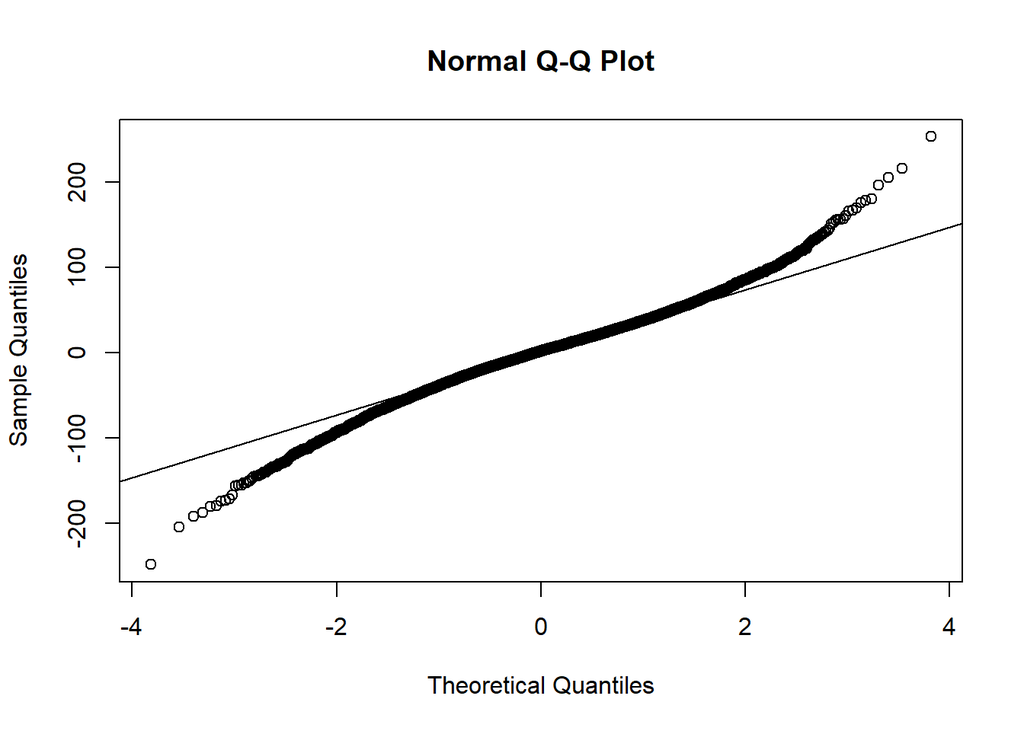

```r
qqnorm(resid(model_sel))
qqline(resid(model_sel))
```

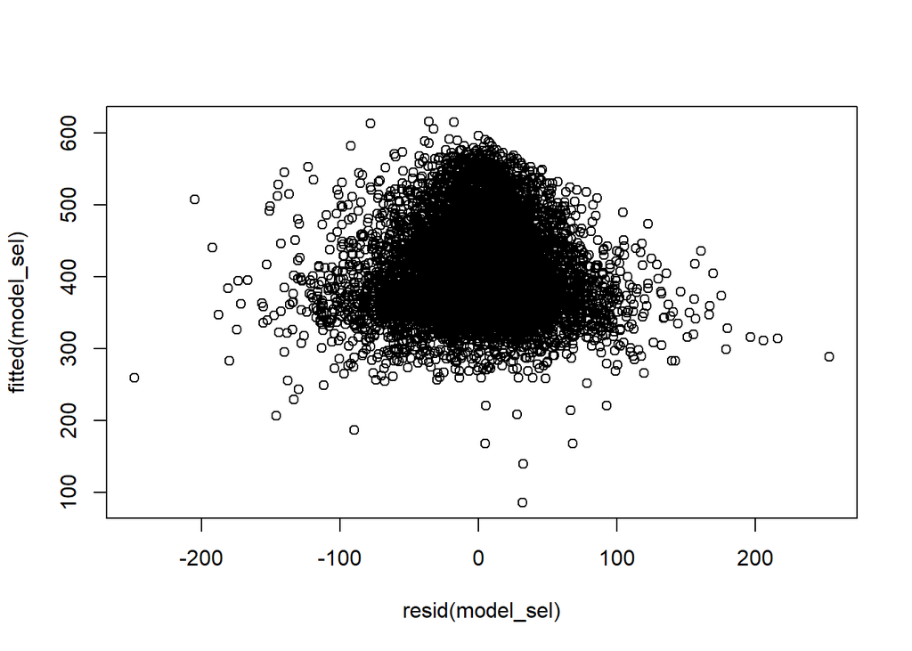

```r
plot(resid(model_sel), fitted(model_sel))
```

BPTest and Shapiro Test

```r
bptest(model_sel)
```

```
##
##  studentized Breusch-Pagan test
##
## data:  model_sel
## BP = 719.53, df = 42, p-value < 2.2e-16
```

```r
shapiro.test(resid(model_sel)[1:3000])
```

```
##
##  Shapiro-Wilk normality test
##
## data:  resid(model_sel)[1:3000]
## W = 0.98419, p-value < 2.2e-16
```

The tests for normality fail. We must now see if we can reduce the model to one that is normally distributed.

### Normality Adjustments

```r
summary(model_sel)
```

```
##
## Call:
## lm(formula = API13 ~ STYPE + CHARTER + VALID + PCT_AA + PCT_AI +
##     PCT_AS + PCT_FI + PCT_HI + PCT_PI + PCT_WH + PCT_MR + MEALS +
##     P_MIGED + P_DI + CBMOB + DMOB + ACS_K3 + ACS_46 + ACS_CORE +
##     NOT_HSG + HSG + SOME_COL + GRAD_SCH + AVG_ED + FULL + EMER +
##     PEN_2 + PEN_35 + PEN_6 + PEN_78 + PEN_911 + ENROLL + PAR_OPT +
##     CW_CSTE + CWS_91 + CW_CSTH + CW_CHSM + CW_SCI + CWM2_28 +
##     CWM2_91 + CWS2_91, data = data_2013)
##
## Residuals:
##      Min       1Q   Median       3Q      Max
## -248.548  -24.127    1.903   25.375  253.378
##
## Coefficients:
##               Estimate Std. Error t value Pr(>|t|)
## (Intercept) 226.207252  13.895330  16.279  < 2e-16 ***
## STYPE6       29.121963   8.665371   3.361 0.000781 ***
## STYPE7       23.175404   3.958211   5.855 4.97e-09 ***
## CHARTERY      4.453062   1.976124   2.253 0.024261 *
## VALID         0.007472   0.002342   3.190 0.001426 **
## PCT_AA       -0.106792   0.021598  -4.944 7.81e-07 ***
## PCT_AI       -0.391522   0.077694  -5.039 4.78e-07 ***
## PCT_AS        0.116359   0.022109   5.263 1.46e-07 ***
## PCT_FI        0.165020   0.039120   4.218 2.49e-05 ***
## PCT_HI        0.132895   0.024686   5.383 7.53e-08 ***
## PCT_PI       -1.699922   0.195737  -8.685  < 2e-16 ***
## PCT_WH       -0.052807   0.022389  -2.359 0.018367 *
## PCT_MR       -0.147940   0.045241  -3.270 0.001080 **
## MEALS        -0.043877   0.019236  -2.281 0.022581 *
## P_MIGED      -0.087060   0.048302  -1.802 0.071524 .
## P_DI          0.149037   0.019903   7.488 7.80e-14 ***
## CBMOB         0.263574   0.047555   5.543 3.08e-08 ***
## DMOB         -0.337005   0.037617  -8.959  < 2e-16 ***
## ACS_K3       -0.790202   0.133978  -5.898 3.84e-09 ***
## ACS_46        0.838217   0.113326   7.396 1.55e-13 ***
## ACS_CORE      0.271538   0.101624   2.672 0.007557 **
## NOT_HSG       0.050517   0.024726   2.043 0.041082 *
## HSG          -0.064835   0.033245  -1.950 0.051186 .
## SOME_COL     -0.053599   0.034026  -1.575 0.115247
```

[output cut: 10 more lines]

```
## PAR_OPT       0.065489   0.038619   1.696 0.089977 .
## CW_CSTE       0.156107   0.033551   4.653 3.33e-06 ***
## CWS_91       -0.121721   0.028833  -4.222 2.45e-05 ***
## CW_CSTH      -0.024163   0.012284  -1.967 0.049218 *
## CW_CHSM       0.124279   0.014089   8.821  < 2e-16 ***
## CW_SCI        0.103162   0.034476   2.992 0.002778 **
## CWM2_28     -13.699697   4.352572  -3.147 0.001653 **
## CWM2_91      -1.731051   0.263379  -6.572 5.29e-11 ***
## CWS2_91      -1.346602   0.348052  -3.869 0.000110 ***
## ---
## Signif. codes:  0 '***' 0.001 '**' 0.01 '*' 0.05 '.' 0.1 ' ' 1
##
## Residual standard error: 42.74 on 7388 degrees of freedom
## Multiple R-squared:  0.7045, Adjusted R-squared:  0.7029
## F-statistic: 419.5 on 42 and 7388 DF,  p-value: < 2.2e-16
```

The last three columns look suspicious.

```r
unique(data_2013$CWM2_28)
```

```
## [1] 1 4 2 3
```

```r
unique(data_2013$CWM2_91)
```

```
##  [1]  3  1  2  6  4  9  5  7 10 11 31 13 12 54 14 77 42 17 16  8 19 15 57
## [24] 78 41 18 33 38 60
```

```r
unique(data_2013$CWS2_91)
```

```
##  [1]  3  1 17  5  8 16  2  4 11 10 26 18 19 20  9  6 12 13  7 27 34 14 15
## [24] 23 24
```

```r
sum(data_2013$CWM2_28==1)
```

```
## [1] 7375
```

```r
sum(data_2013$CWM2_28==2)
```

```
## [1] 47
```

```r
sum(data_2013$CWM2_28==3)
```

```
## [1] 5
```

```r
sum(data_2013$CWM2_28==4)
```

```
## [1] 4
```

```r
# Remove these columns from the model and re-fit
model_init = lm(formula = API13 ~ STYPE + CHARTER + VALID + PCT_AA + PCT_AI +
    PCT_AS + PCT_FI + PCT_HI + PCT_PI + PCT_WH + PCT_MR + MEALS +
    P_MIGED + P_DI + CBMOB + DMOB + ACS_K3 + ACS_46 + ACS_CORE +
    NOT_HSG + HSG + SOME_COL + GRAD_SCH + AVG_ED + FULL + EMER +
    PEN_2 + PEN_35 + PEN_6 + PEN_78 + PEN_911 + ENROLL + PAR_OPT +
    CW_CSTE + CWS_91 + CW_CSTH + CW_CHSM + CW_SCI, data = data_2013)
model = step(model_init, trace=0)
summary(model)
```

```
##
## Call:
## lm(formula = API13 ~ STYPE + CHARTER + VALID + PCT_AA + PCT_AI +
##     PCT_AS + PCT_FI + PCT_HI + PCT_PI + PCT_WH + PCT_MR + MEALS +
##     P_MIGED + P_DI + CBMOB + DMOB + ACS_K3 + ACS_46 + ACS_CORE +
##     NOT_HSG + HSG + SOME_COL + GRAD_SCH + AVG_ED + FULL + EMER +
##     PEN_2 + PEN_35 + PEN_6 + PEN_78 + PEN_911 + ENROLL + CW_CSTE +
##     CWS_91 + CW_CSTH + CW_CHSM + CW_SCI, data = data_2013)
##
## Residuals:
##      Min       1Q   Median       3Q      Max
## -242.267  -24.046    2.068   25.289  262.210
##
## Coefficients:
##               Estimate Std. Error t value Pr(>|t|)
## (Intercept) 200.483788  13.309553  15.063  < 2e-16 ***
## STYPE6       18.459437   8.603717   2.146 0.031944 *
## STYPE7       22.415966   3.983706   5.627 1.90e-08 ***
## CHARTERY      4.614998   1.986184   2.324 0.020177 *
## VALID         0.009426   0.002356   4.001 6.37e-05 ***
## PCT_AA       -0.104632   0.021784  -4.803 1.59e-06 ***
## PCT_AI       -0.436617   0.078242  -5.580 2.49e-08 ***
## PCT_AS        0.119929   0.022293   5.380 7.69e-08 ***
## PCT_FI        0.177968   0.039422   4.514 6.45e-06 ***
## PCT_HI        0.141347   0.024882   5.681 1.39e-08 ***
## PCT_PI       -1.735839   0.197352  -8.796  < 2e-16 ***
## PCT_WH       -0.057223   0.022574  -2.535 0.011267 *
## PCT_MR       -0.160027   0.045621  -3.508 0.000455 ***
## MEALS        -0.037923   0.019380  -1.957 0.050414 .
## P_MIGED      -0.103212   0.048700  -2.119 0.034095 *
## P_DI          0.150850   0.020063   7.519 6.17e-14 ***
## CBMOB         0.300755   0.047788   6.294 3.28e-10 ***
## DMOB         -0.358634   0.037876  -9.469  < 2e-16 ***
## ACS_K3       -0.751874   0.134898  -5.574 2.58e-08 ***
## ACS_46        0.769250   0.113988   6.749 1.61e-11 ***
## ACS_CORE      0.295016   0.102308   2.884 0.003943 **
## NOT_HSG       0.052915   0.024930   2.123 0.033825 *
## HSG          -0.066299   0.033516  -1.978 0.047949 *
## SOME_COL     -0.056102   0.034310  -1.635 0.102057
## GRAD_SCH     -0.071891   0.022085  -3.255 0.001138 **
## AVG_ED        0.790824   0.011855  66.710  < 2e-16 ***
## FULL         -0.393006   0.072514  -5.420 6.16e-08 ***
## EMER         -0.058839   0.040629  -1.448 0.147607
## PEN_2        -0.259397   0.075994  -3.413 0.000645 ***
## PEN_35        0.130295   0.060376   2.158 0.030956 *
## PEN_6        -0.223810   0.067286  -3.326 0.000884 ***
## PEN_78        0.187113   0.053283   3.512 0.000448 ***
## PEN_911      -0.778929   0.082844  -9.402  < 2e-16 ***
## ENROLL       -0.005145   0.002220  -2.317 0.020513 *
## CW_CSTE       0.178930   0.033730   5.305 1.16e-07 ***
## CWS_91       -0.106670   0.028416  -3.754 0.000175 ***
## CW_CSTH      -0.032508   0.012362  -2.630 0.008563 **
## CW_CHSM       0.147390   0.014027  10.508  < 2e-16 ***
## CW_SCI        0.119951   0.034740   3.453 0.000558 ***
## ---
## Signif. codes:  0 '***' 0.001 '**' 0.01 '*' 0.05 '.' 0.1 ' ' 1
##
## Residual standard error: 43.11 on 7392 degrees of freedom
## Multiple R-squared:  0.6992, Adjusted R-squared:  0.6977
## F-statistic: 452.2 on 38 and 7392 DF,  p-value: < 2.2e-16
```

```r
bptest(model)
```

```
##
##  studentized Breusch-Pagan test
##
## data:  model
## BP = 734.53, df = 38, p-value < 2.2e-16
```

```r
shapiro.test(resid(model)[1:3000])
```

```
##
##  Shapiro-Wilk normality test
##
## data:  resid(model)[1:3000]
## W = 0.98104, p-value < 2.2e-16
```

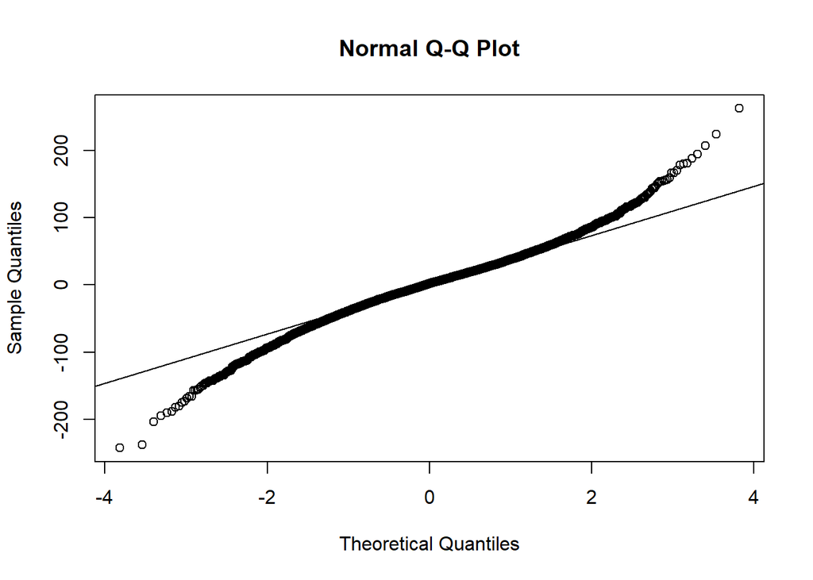

```r
qqnorm(resid(model))
qqline(resid(model))
```

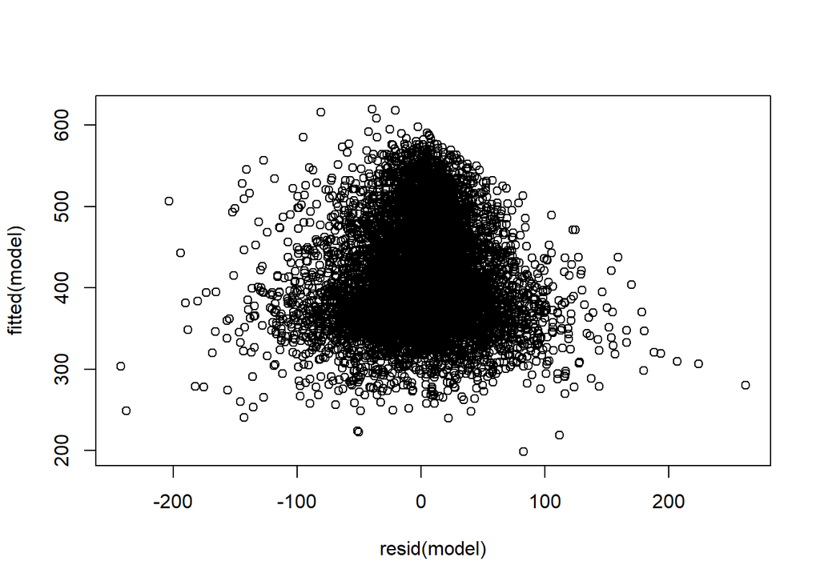

```r
plot(resid(model), fitted(model))
```

Next we look at the `pairs` plot to see if any of the predictors are collinear.

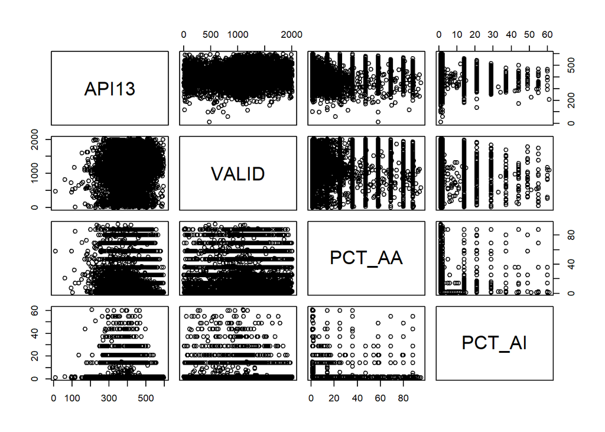

```r
pairs(subset(data_2013,select=c('API13', 'VALID', 'PCT_AA', 'PCT_AI')))
```

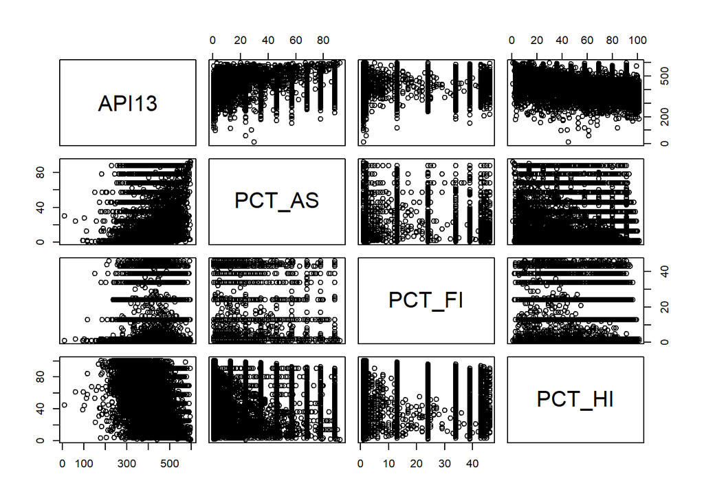

```r
pairs(subset(data_2013,select=c('API13', 'PCT_AS', 'PCT_FI', 'PCT_HI')))
```

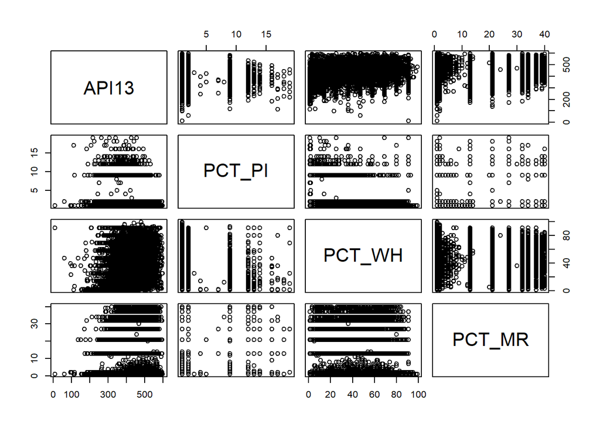

```r
pairs(subset(data_2013,select=c('API13', 'PCT_PI', 'PCT_WH', 'PCT_MR')))
```

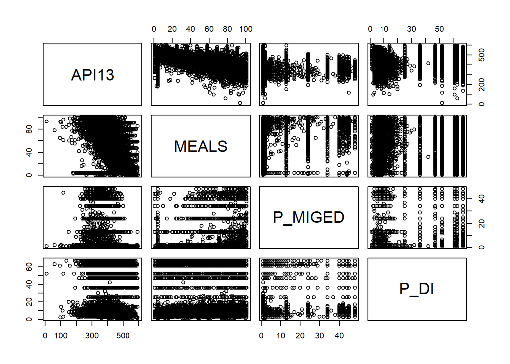

```r
pairs(subset(data_2013,select=c('API13', 'MEALS', 'P_MIGED', 'P_DI')))
```

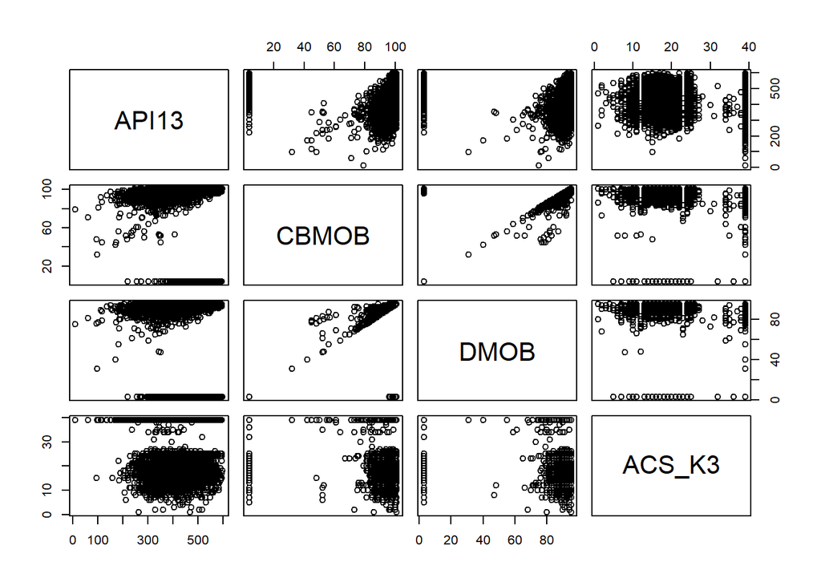

```r
pairs(subset(data_2013,select=c('API13', 'CBMOB', 'DMOB', 'ACS_K3')))
```

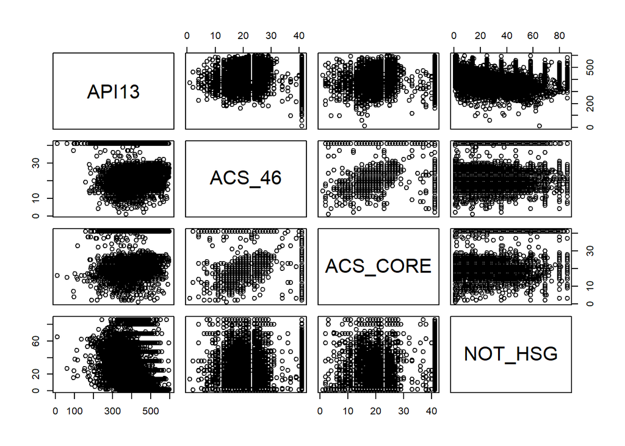

```r
pairs(subset(data_2013,select=c('API13', 'ACS_46', 'ACS_CORE', 'NOT_HSG')))
```

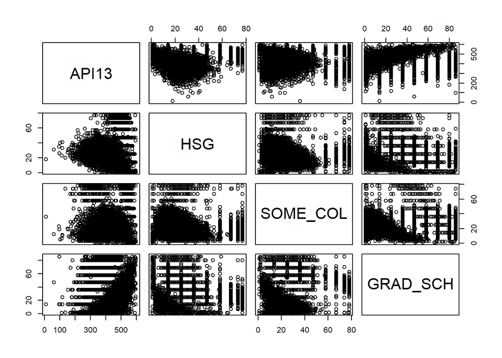

```r
pairs(subset(data_2013,select=c('API13', 'HSG', 'SOME_COL', 'GRAD_SCH')))
```

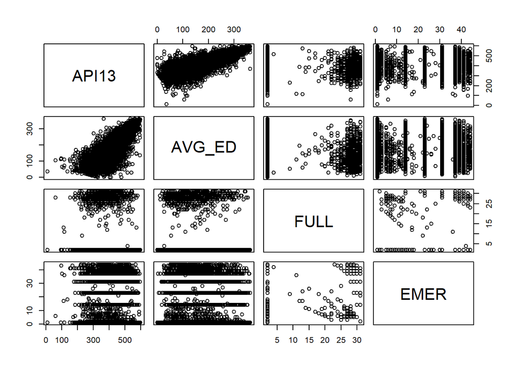

```r
pairs(subset(data_2013,select=c('API13', 'AVG_ED', 'FULL', 'EMER')))
```

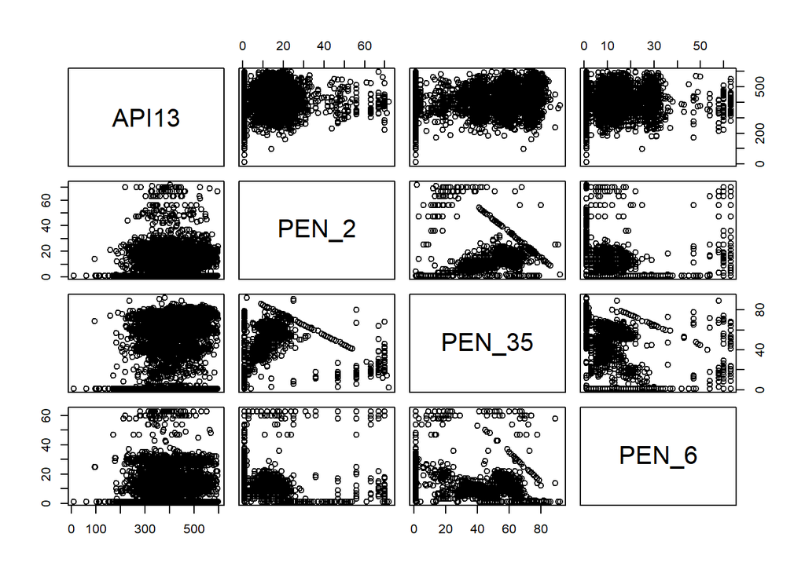

```r
pairs(subset(data_2013,select=c('API13', 'PEN_2', 'PEN_35', 'PEN_6')))
```

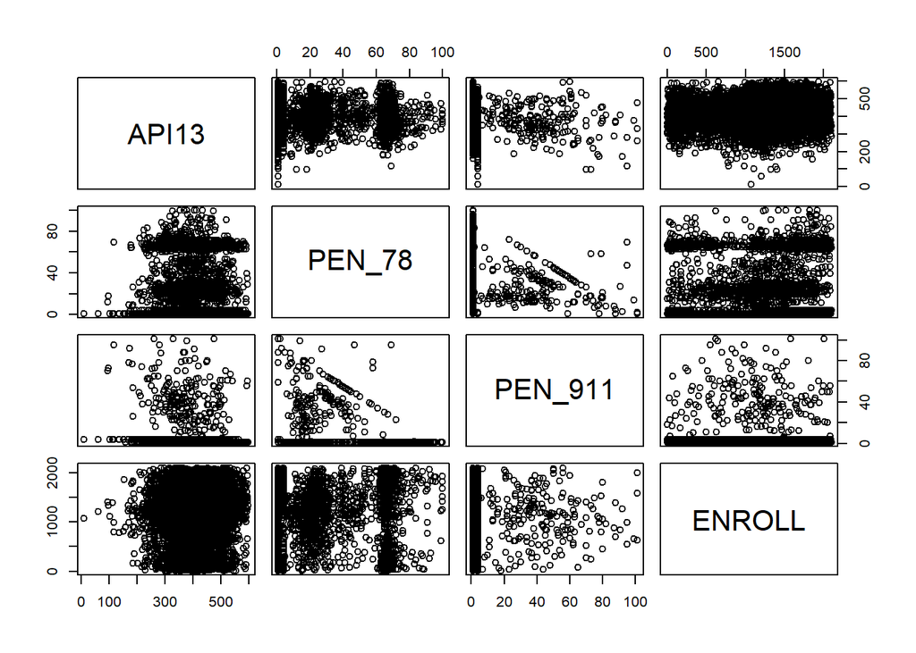

```r
pairs(subset(data_2013,select=c('API13', 'PEN_78', 'PEN_911', 'ENROLL')))
```

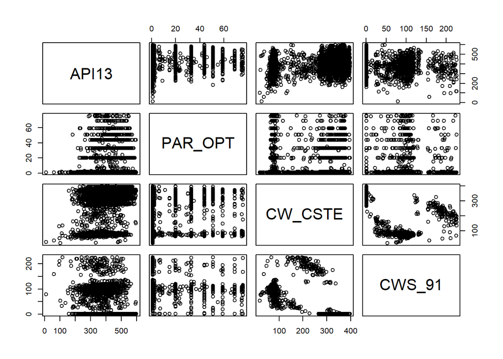

```r
pairs(subset(data_2013,select=c('API13', 'PAR_OPT', 'CW_CSTE', 'CWS_91')))
```

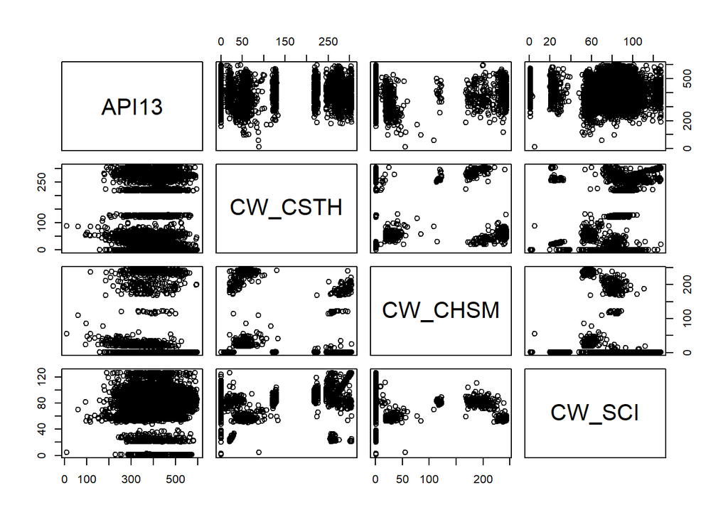

```r
pairs(subset(data_2013,select=c('API13', 'CW_CSTH', 'CW_CHSM', 'CW_SCI')))
```

It looks like the following fields may be collinear: DMOB with CBMOB, PEN_2 with PEN_35, PEN_6, PEN_78, and PEN_911. The collinear columns will be removed.

The following fields look like they can use a `log()` transform: PCT_AA, PCT_AS, P_MIGED, P_DI, CBMOB, and FULL.

### Striated Sub-Sampling

```r
# Apply backwards AIC to the given model and plot the QQPlot and residual vs fitted
model_it = function(a_model) {
  opt_model = step(a_model, trace=0)
  qqnorm(resid(opt_model))
  qqline(resid(opt_model))
  plot(resid(opt_model), fitted(opt_model))
  opt_model
}
```

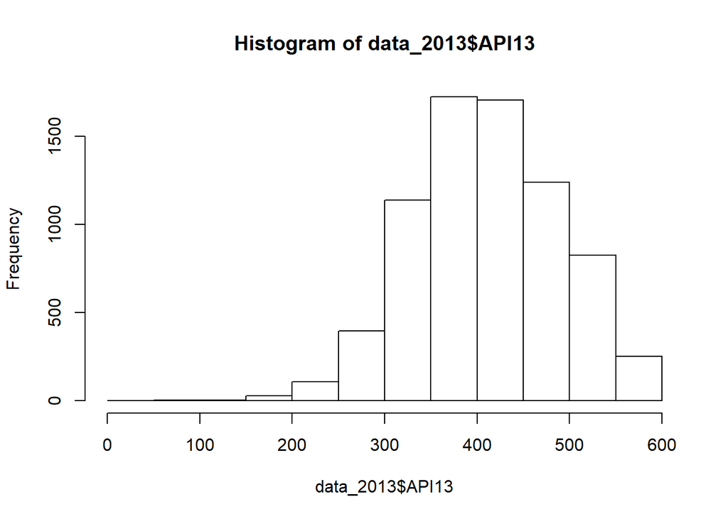

```r
# Data still not passing normality tests.
# Try striated partitions: 30 random samples for range 11-598
randomly_select = function(dframe, no_to_select) {
  dframe[sample(nrow(dframe), no_to_select), ] # it's up to the caller to make sure there are enough rows
}

striation_subsample = function(dframe, response, no_bins = 20, bin_size = 30) {
  range_response = range(dframe[, response])
  response_interval = (range_response[2] - range_response[1])/no_bins
  no_breaks = seq(range_response[1], range_response[2], by=response_interval)

  reduced_data = data.frame(dframe[0,]) # First add the column headers only
  for(i in seq(range_response[1], range_response[2], by=response_interval)) {
    interval_rows = dframe[, response] >= i & dframe[, response] < (i + response_interval)

    no_rows_in_interval = nrow(dframe[interval_rows,])

    print(paste(i,' => ',no_rows_in_interval,' elts'))
    if (no_rows_in_interval > bin_size) {
      reduced_data = rbind(reduced_data,
                           randomly_select(subset(dframe, subset = interval_rows),
                                           bin_size))
    } else { # add the entire bin to the resulting dataset
      reduced_data = rbind(reduced_data,
                           subset(dframe, subset = interval_rows))
    }
  }
  print(paste('Reduced model has',nrow(reduced_data),'rows'))
  reduced_data
}

hist(data_2013$API13)
```

```r
reduced_data = striation_subsample(data_2013, 'API13', 20, 30)
```

```
## [1] "11  =>  1  elts"
## [1] "40.35  =>  1  elts"
## [1] "69.7  =>  2  elts"
## [1] "99.05  =>  4  elts"
## [1] "128.4  =>  3  elts"
## [1] "157.75  =>  16  elts"
## [1] "187.1  =>  23  elts"
## [1] "216.45  =>  77  elts"
## [1] "245.8  =>  159  elts"
## [1] "275.15  =>  316  elts"
## [1] "304.5  =>  584  elts"
## [1] "333.85  =>  926  elts"
## [1] "363.2  =>  1001  elts"
## [1] "392.55  =>  1055  elts"
## [1] "421.9  =>  968  elts"
## [1] "451.25  =>  767  elts"
## [1] "480.6  =>  648  elts"
## [1] "509.95  =>  481  elts"
## [1] "539.3  =>  302  elts"
## [1] "568.65  =>  96  elts"
## [1] "598  =>  1  elts"
## [1] "Reduced model has 441 rows"
```

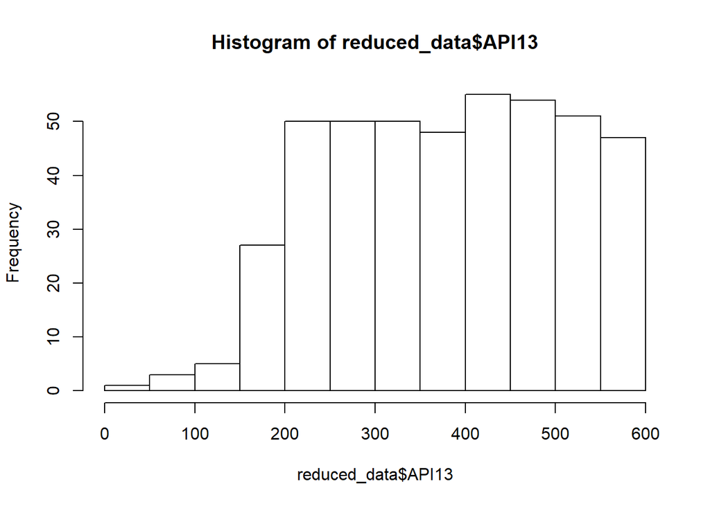

```r
hist(reduced_data$API13)
```

```r
# Test reduced model; STYPE and VALID showed high collinearity in a VIF output so those were removed
model_init = lm(API13 ~ CHARTER + log(PCT_AA) + PCT_AI +
                  log(PCT_AS) + PCT_FI + PCT_HI + PCT_PI + PCT_WH + PCT_MR + MEALS +
                  log(P_MIGED) + log(P_DI) + log(CBMOB) + ACS_K3 + ACS_46 + ACS_CORE +
                  NOT_HSG + HSG + SOME_COL + GRAD_SCH + AVG_ED + log(FULL) + EMER +
                  ENROLL + PAR_OPT +
                  CWS_91 + CW_CSTH + CW_CHSM + CW_SCI, data = reduced_data)
print("Model Optimization 1")
```

```
## [1] "Model Optimization 1"
```

```r
model_opt1 = model_it(model_init)
```

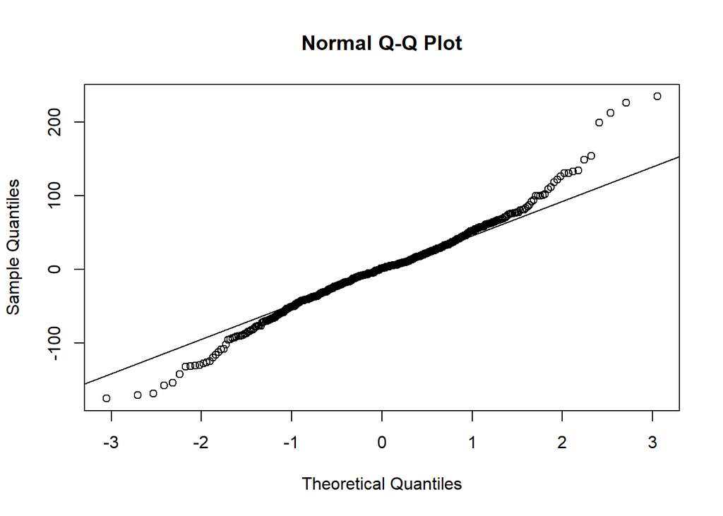

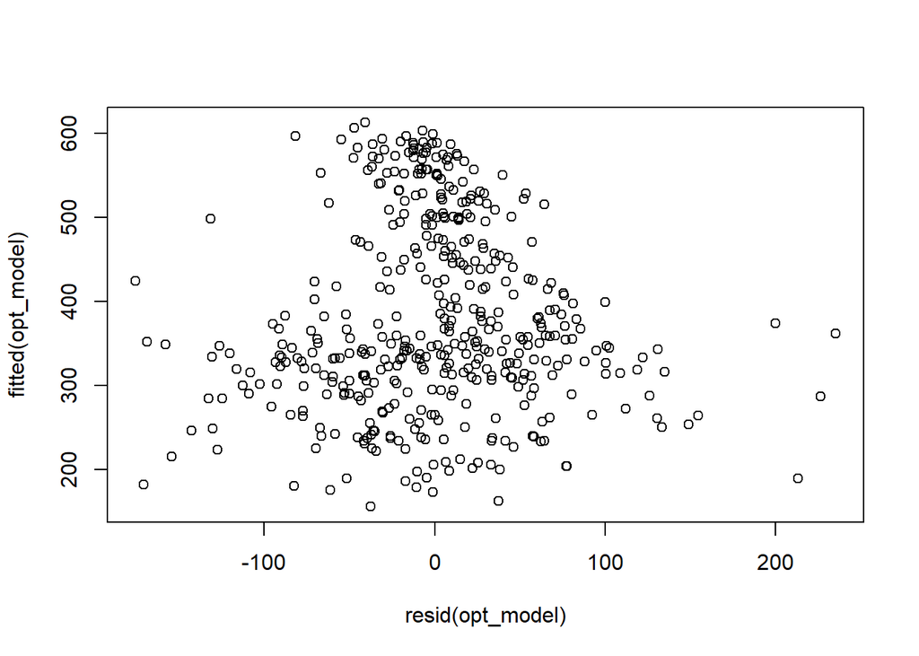

```r
summary(model_opt1)
```

```
##
## Call:
## lm(formula = API13 ~ log(PCT_AA) + PCT_AI + PCT_FI + PCT_HI +
##     PCT_PI + MEALS + log(P_MIGED) + ACS_K3 + ACS_CORE + GRAD_SCH +
##     AVG_ED + log(FULL) + CWS_91 + CW_CSTH + CW_CHSM, data = reduced_data)
##
## Residuals:
##      Min       1Q   Median       3Q      Max
## -175.489  -32.590    1.282   30.677  235.096
##
## Coefficients:
##               Estimate Std. Error t value Pr(>|t|)
## (Intercept)  210.25337   27.26383   7.712 8.89e-14 ***
## log(PCT_AA)   -5.09270    2.17080  -2.346  0.01943 *
## PCT_AI        -1.07247    0.39962  -2.684  0.00756 **
## PCT_FI         0.49268    0.21992   2.240  0.02559 *
## PCT_HI         0.30195    0.12499   2.416  0.01612 *
## PCT_PI        -2.96644    1.03770  -2.859  0.00446 **
## MEALS         -0.21228    0.09702  -2.188  0.02922 *
## log(P_MIGED)   5.48552    2.70695   2.026  0.04334 *
## ACS_K3        -0.70589    0.39769  -1.775  0.07662 .
## ACS_CORE       1.26484    0.43172   2.930  0.00357 **
## GRAD_SCH      -0.24477    0.13653  -1.793  0.07372 .
## AVG_ED         1.05529    0.04945  21.342  < 2e-16 ***
## log(FULL)     -5.07846    3.35421  -1.514  0.13076
## CWS_91        -0.45312    0.08766  -5.169 3.63e-07 ***
## CW_CSTH        0.06570    0.03774   1.741  0.08241 .
## CW_CHSM        0.12964    0.06624   1.957  0.05098 .
## ---
## Signif. codes:  0 '***' 0.001 '**' 0.01 '*' 0.05 '.' 0.1 ' ' 1
##
## Residual standard error: 59.08 on 425 degrees of freedom
## Multiple R-squared:  0.7916, Adjusted R-squared:  0.7843
## F-statistic: 107.6 on 15 and 425 DF,  p-value: < 2.2e-16
```

```r
bptest(model_opt1)
```

```
##
##  studentized Breusch-Pagan test
##
## data:  model_opt1
## BP = 40.061, df = 15, p-value = 0.0004441
```

```r
shapiro.test(resid(model_opt1))
```

```
##
##  Shapiro-Wilk normality test
##
## data:  resid(model_opt1)
## W = 0.97726, p-value = 2.182e-06
```

```r
print("After cooks distance applied")
```

```
## [1] "After cooks distance applied"
```

```r
cd = cooks.distance(model_opt1)
no_outlier_data = subset(reduced_data, subset = cd < 3/length(cd)) # using an aggressive cooks distance criteria
print(paste(nrow(no_outlier_data),"rows left"))
```

```
## [1] "398 rows left"
```

```r
model_init2 = lm(API13 ~ CHARTER + log(PCT_AA) + PCT_AI +
                   log(PCT_AS) + PCT_FI + PCT_HI + PCT_PI + PCT_WH + PCT_MR + MEALS +
                   log(P_MIGED) + log(P_DI) + log(CBMOB) + ACS_K3 + ACS_46 + ACS_CORE +
                   NOT_HSG + HSG + SOME_COL + GRAD_SCH + AVG_ED + log(FULL) + EMER +
                   ENROLL + PAR_OPT +
                   CWS_91 + CW_CSTH + CW_CHSM + CW_SCI, data = no_outlier_data)
print("Model Optimization 2")
```

```
## [1] "Model Optimization 2"
```

```r
model_opt2 = model_it(model_init2)
```

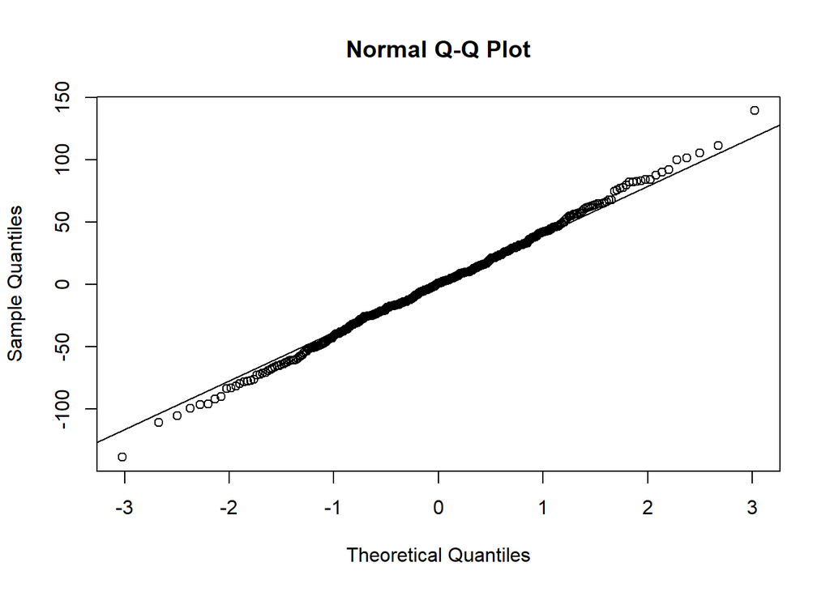

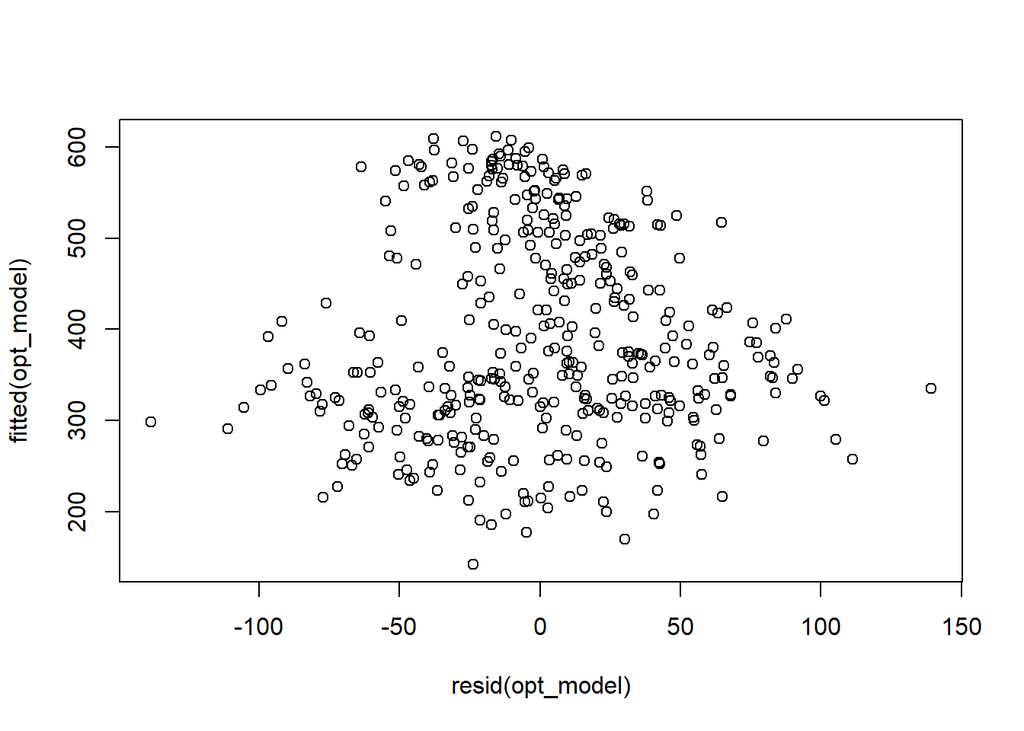

```r
summary(model_opt2)
```

```
##
## Call:
## lm(formula = API13 ~ log(PCT_AA) + PCT_AI + log(PCT_AS) + PCT_FI +
##     PCT_HI + PCT_PI + MEALS + log(P_MIGED) + log(P_DI) + ACS_CORE +
##     GRAD_SCH + AVG_ED + log(FULL) + CWS_91 + CW_CHSM, data = no_outlier_data)
##
## Residuals:
##      Min       1Q   Median       3Q      Max
## -138.522  -25.432    0.947   27.208  139.221
##
## Coefficients:
##               Estimate Std. Error t value Pr(>|t|)
## (Intercept)  205.02166   15.84680  12.938  < 2e-16 ***
## log(PCT_AA)   -5.52375    1.69118  -3.266  0.00119 **
## PCT_AI        -0.62505    0.36884  -1.695  0.09096 .
## log(PCT_AS)    5.44304    1.78762   3.045  0.00249 **
## PCT_FI         0.38832    0.17319   2.242  0.02553 *
## PCT_HI         0.27113    0.09776   2.773  0.00582 **
## PCT_PI        -3.85176    0.83158  -4.632 4.98e-06 ***
## MEALS         -0.18797    0.07510  -2.503  0.01273 *
## log(P_MIGED)   3.87091    2.13952   1.809  0.07120 .
## log(P_DI)      2.83243    1.93124   1.467  0.14330
## ACS_CORE       0.92403    0.22399   4.125 4.55e-05 ***
## GRAD_SCH      -0.16940    0.11011  -1.538  0.12477
## AVG_ED         0.99301    0.04225  23.502  < 2e-16 ***
## log(FULL)     -6.71936    2.70216  -2.487  0.01332 *
## CWS_91        -0.52587    0.07631  -6.891 2.29e-11 ***
## CW_CHSM        0.12599    0.05533   2.277  0.02333 *
## ---
## Signif. codes:  0 '***' 0.001 '**' 0.01 '*' 0.05 '.' 0.1 ' ' 1
##
## Residual standard error: 43.05 on 382 degrees of freedom
## Multiple R-squared:  0.8769, Adjusted R-squared:  0.8721
## F-statistic: 181.5 on 15 and 382 DF,  p-value: < 2.2e-16
```

```r
bptest(model_opt2)
```

```
##
##  studentized Breusch-Pagan test
##
## data:  model_opt2
## BP = 68.248, df = 15, p-value = 9.147e-09
```

```r
shapiro.test(resid(model_opt2))
```

```
##
##  Shapiro-Wilk normality test
##
## data:  resid(model_opt2)
## W = 0.99872, p-value = 0.9936
```

```r
# check collinearity
car::vif(model_opt2)
```

```
##  log(PCT_AA)       PCT_AI  log(PCT_AS)       PCT_FI       PCT_HI
##     1.311825     1.078783     1.634239     1.234861     1.897754
##       PCT_PI        MEALS log(P_MIGED)    log(P_DI)     ACS_CORE
##     1.159398     1.433628     1.490676     1.083880     1.409723
##     GRAD_SCH       AVG_ED    log(FULL)       CWS_91      CW_CHSM
##     1.418702     3.614493     1.095907     2.682974     2.306498
```

## Conclusions 2013

Even though the bptest rejected the null hypothesis of a constant variance, the `Fitted vs Residual` plot doesn’t show any discernible patterns. The Shapiro test failed to reject the null hypothesis that the data was sampled from a normal distribution. The `vif()` check doesn’t show collinearity for any of the final set of predictors. The QQ-Plot looks good.

When this script is run repeatedly, there are two large influencers that emerge. One case looks like this:

```r
final1 = lm(API13 ~ log(PCT_AA) + PCT_FI + PCT_HI + PCT_PI +
              log(P_MIGED) + log(CBMOB) + ACS_46 + ACS_CORE + HSG + AVG_ED +
              EMER + CWS_91 + CW_CSTH + CW_CHSM, data=no_outlier_data)
bptest(final1)
```

```
##
##  studentized Breusch-Pagan test
##
## data:  final1
## BP = 45.89, df = 14, p-value = 2.922e-05
```

```r
shapiro.test(resid(final1))
```

```
##
##  Shapiro-Wilk normality test
##
## data:  resid(final1)
## W = 0.99603, p-value = 0.4211
```

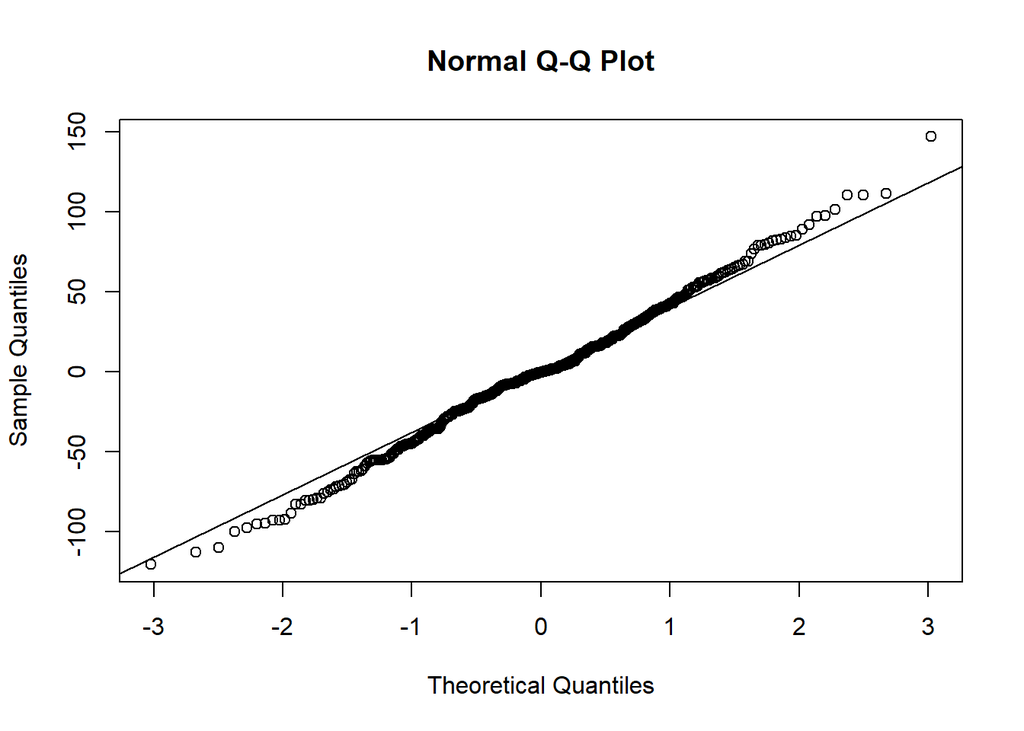

```r
qqnorm(resid(final1))
qqline(resid(final1))
```

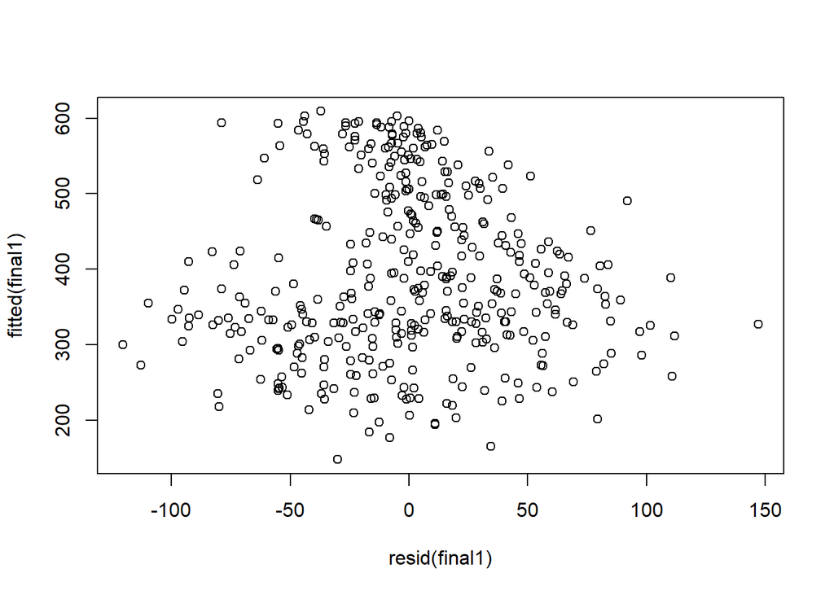

```r
plot(resid(final1), fitted(final1))
```

```r
summary(final1)$adj
```

```
## [1] 0.8643983
```

```r
coef(final1)
```

```
##  (Intercept)  log(PCT_AA)       PCT_FI       PCT_HI       PCT_PI
## 165.81783549  -6.54919942   0.57936170   0.28354143  -3.73016146
## log(P_MIGED)   log(CBMOB)       ACS_46     ACS_CORE          HSG
##   2.06633706   3.44356572   0.05258757   1.14468371   0.15126700
##       AVG_ED         EMER       CWS_91      CW_CSTH      CW_CHSM
##   1.05392236  -0.39207993  -0.55097732   0.03520797   0.15199278
```

The other case looks like this:

```r
final2 = lm(API13 ~ CHARTER + log(PCT_AA) + PCT_FI + PCT_HI +
              PCT_PI + log(P_DI) + ACS_46 + ACS_CORE + GRAD_SCH + AVG_ED +
              EMER + CWS_91 + CW_CHSM + CW_SCI, data=no_outlier_data)
bptest(final2)
```

```
##
##  studentized Breusch-Pagan test
##
## data:  final2
## BP = 64.993, df = 14, p-value = 1.534e-08
```

```r
shapiro.test(resid(final2))
```

```
##
##  Shapiro-Wilk normality test
##
## data:  resid(final2)
## W = 0.9965, p-value = 0.5383
```

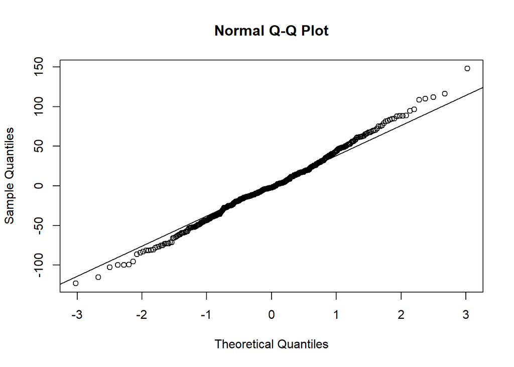

```r
qqnorm(resid(final2))
qqline(resid(final2))
```

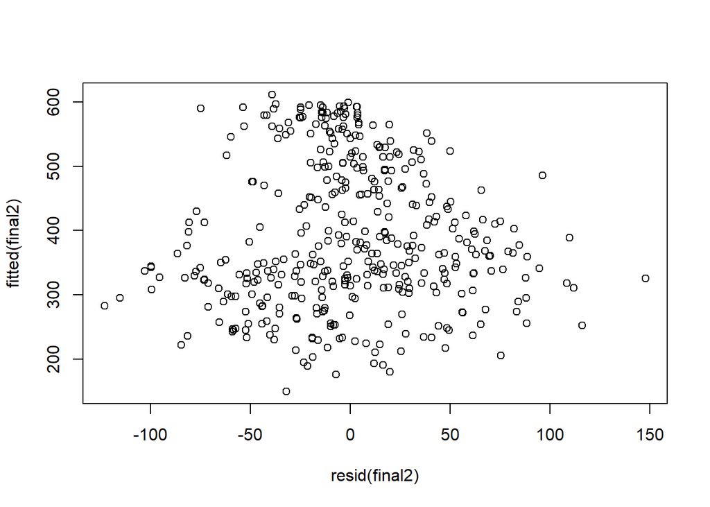

```r
plot(resid(final2), fitted(final2))
```

```r
summary(final2)$adj
```

```
## [1] 0.8651897
```

```r
coef(final2)
```

```
##  (Intercept)     CHARTERY  log(PCT_AA)       PCT_FI       PCT_HI
## 192.17376979  -8.93562978  -6.33049801   0.55910594   0.30568163
##       PCT_PI    log(P_DI)       ACS_46     ACS_CORE     GRAD_SCH
##  -3.68062879   2.71004262  -0.05961794   0.89405094  -0.18029844
##       AVG_ED         EMER       CWS_91      CW_CHSM       CW_SCI
##   1.05831233  -0.33404420  -0.55518698   0.14856408   0.04065505
```

In the end, the largest influencers of performance are:

- CBMOB - whether the student doesn’t skip school day for more than 30 consecutive days from when the school starts
- AVG_ED - the parent’s education level
- ACS_CORE - the class size
- CHARTER - whether the school is a charter school or not
- PCT_AA and PCT_PI - the presence of some disadvantaged minority and ethnic groups

It’s important to note that these influencers illustrate correlation and not causation.